# Tree-Based Methods in Machine Learning

For DATA50XX by ctong

## Overview

### What is a Decision Tree?

A **decision tree** is a type of model used in machine learning for both classification and regression problems. It works like a flowchart: you start at the top (the “root”), and at each step (called a “node”), you ask a question about the data. Depending on the answer, you move down one branch of the tree to the next node, until you reach a final decision (a “leaf”).

**Benefits:**

- Easy to understand and interpret.
- Can handle both numerical and categorical data.
- Requires little data preprocessing.

**Limitations:**

- Prone to overfitting (creating overly complex trees that do not generalize well).
- Small changes in data can lead to very different trees.
- Not as accurate as some ensemble methods unless properly tuned.

### How do Decision Trees Choose Where to Split?

At each step, the tree chooses the best way to split the data based on a **splitting criterion**. The criterion depends on the type of problem:

**Classification Trees:** The goal is to make each group (branch) as “pure” as possible, meaning most of the data in each group is from the same class.

- The most common criterion is **Gini impurity**, which measures how mixed the classes are in a group.
- Another option is **Information Gain** (based on entropy), which measures how much information a split provides about the classes.

**Regression Trees:** The goal is to make each group as similar as possible in terms of the outcome (a numeric value).

- The most common criterion is to **minimize the sum of squared errors** within each group.
- In other words, each split aims to put together data points with similar target values.

At each split, the algorithm evaluates all possible ways to split the data using these criteria and chooses the one that improves group “purity” or reduces error the most.

### Overfitting and Pruning

A tree that is grown to its maximum size can perfectly fit the training data, but this often means it has become too complex and is capturing noise or random quirks (overfitting). - **Pruning** simplifies the tree by **removing unnecessary branches from a decision tree** after it has been grown, keeping only the splits that provide real value. - The goal is a **simpler model that generalizes better** to new data.

Most decision tree algorithms, such as those used in R (`rpart`), automatically use pruning based on cross-validation or a complexity parameter, so the final tree balances fit and simplicity.

### Example: Decision Tree for Classification

Suppose we want to classify whether a customer will buy a product based on age and income.

```
Is Age < 30?
├── Yes: Is Income > $40K?
│   ├── Yes: Buy
│   └── No: Not Buy
└── No: Buy
```

### Example: Decision Tree for Regression

Suppose we want to predict house prices based on size and location.

```
Is Size < 1200 sq ft?
├── Yes: Is Location = Suburb?
│   ├── Yes: $300,000
│   └── No: $250,000
└── No: $400,000
```

In regression trees, each leaf contains a predicted value, usually the average of observations in that group.

## Classification Demo

```r
# Load required packages
library(caret)
```

```r
library(rpart)
library(rpart.plot)
```

### Using Decision Trees for Classification

We will use the `iris` dataset to predict the species of a flower based on its petal and sepal dimensions.

#### Hyperparameters in Decision Trees (`rpart`)

- **cp (Complexity Parameter):** Controls the cost/penalty for adding more splits (branches) to the tree. A smaller value allows a more complex tree; a larger value results in a simpler tree.
- **maxdepth:** Maximum depth of any node of the final tree (not tuned by default in caret).
- **minsplit:** Minimum number of observations that must exist in a node for a split to be attempted.

```r
# Prepare data
data(iris)
set.seed(123)
# Set up cross-validation
control <- trainControl(method = "cv", number = 3)

# Fit decision tree model with cross-validation and hyperparameter tuning
model_class <- train(
  Species ~ .,
  data = iris,
  method = "rpart",
  trControl = control,
  tuneLength = 3 # tries complexity parameters
)

# Print best model and results
print(model_class)
```

```
## CART
##
## 150 samples
##   4 predictor
##   3 classes: 'setosa', 'versicolor', 'virginica'
##
## No pre-processing
## Resampling: Cross-Validated (3 fold)
## Summary of sample sizes: 100, 101, 99
## Resampling results across tuning parameters:
##
##   cp    Accuracy   Kappa
##   0.00  0.9198479  0.8797737
##   0.44  0.8283447  0.7425188
##   0.50  0.4354649  0.1616162
##
## Accuracy was used to select the optimal model using the largest value.
## The final value used for the model was cp = 0.
```

#### Interpreting the Output

- **Accuracy:** Percentage of correct predictions (for each fold).
- **Kappa:** Measures how much better the model is than random guessing.
- **Best Tuning Parameter:** The value of `cp` that gave the highest accuracy.

#### Visualize the Best Tree

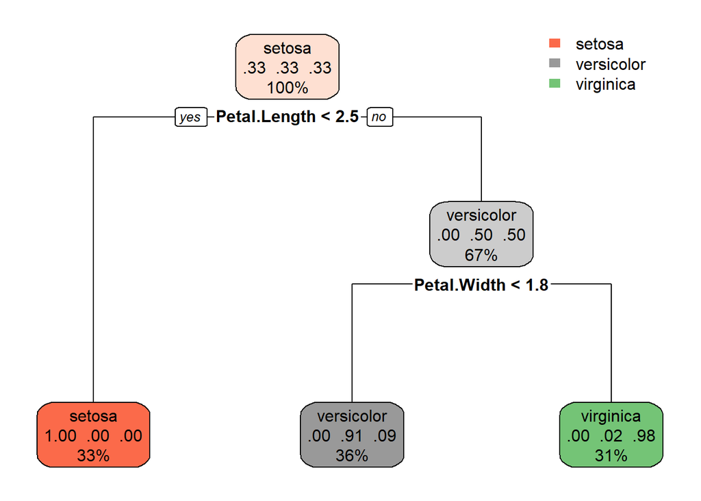

```r
# Plot the best tree
rpart.plot(model_class$finalModel)
```

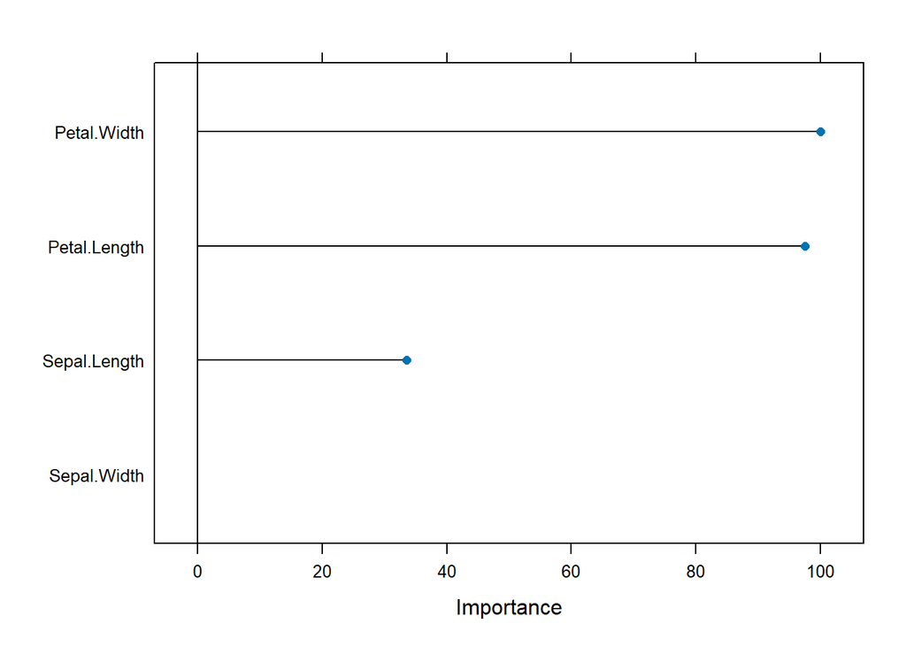

```r
# Plot variable importance
plot(varImp(model_class))
```

## Regression Demo

### Using Decision Trees for Regression

We will use the `Boston` dataset (from the `MASS` package) to predict median house value.

#### Hyperparameters in Regression Trees

- Same as for classification: **cp, maxdepth, minsplit**.

```r
library(MASS)
data(Boston)

# Set up cross-validation
control <- trainControl(method = "cv", number = 3)

set.seed(123)
# Fit regression tree model
model_regr <- train(
  medv ~ .,
  data = Boston,
  method = "rpart",
  trControl = control,
  tuneLength = 3
)
# Print results
print(model_regr)
```

```
## CART
##
## 506 samples
##  13 predictor
##
## No pre-processing
## Resampling: Cross-Validated (3 fold)
## Summary of sample sizes: 337, 337, 338
## Resampling results across tuning parameters:
##
##   cp          RMSE      Rsquared   MAE
##   0.07165784  5.778025  0.6055593  3.998064
##   0.17117244  6.709521  0.4629763  4.850994
##   0.45274420  7.840414  0.3939460  5.750652
##
## RMSE was used to select the optimal model using the smallest value.
## The final value used for the model was cp = 0.07165784.
```

#### Interpreting the Output

- **RMSE (Root Mean Squared Error):** Measures average difference between predicted and actual values.
- **Rsquared:** Proportion of the variance in the dependent variable that is predictable from the independent variables.
- **Best Tuning Parameter:** The value of `cp` with lowest RMSE.

#### Visualize the Best Regression Tree

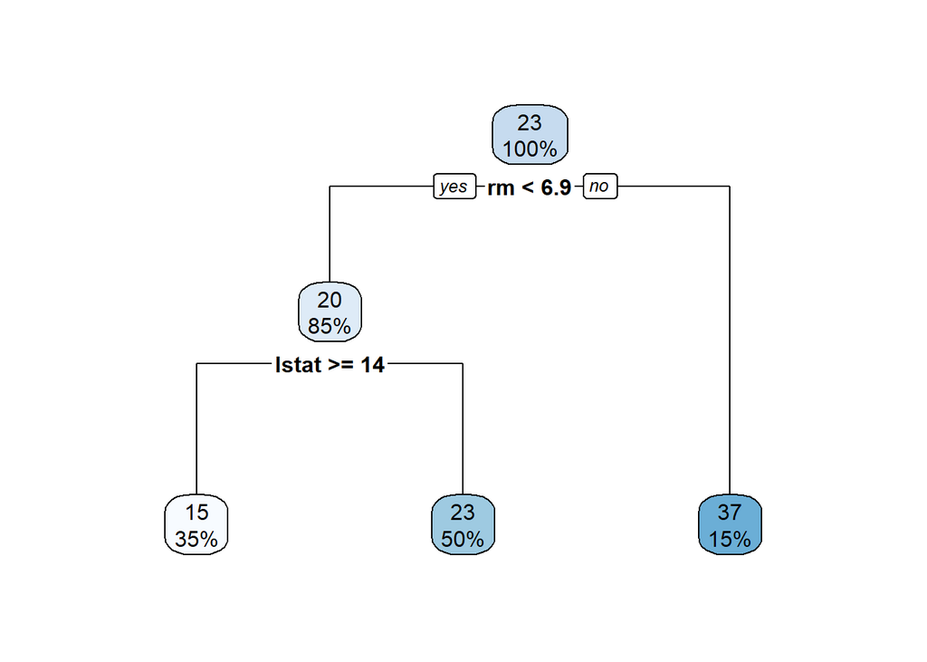

```r
rpart.plot(model_regr$finalModel)
```

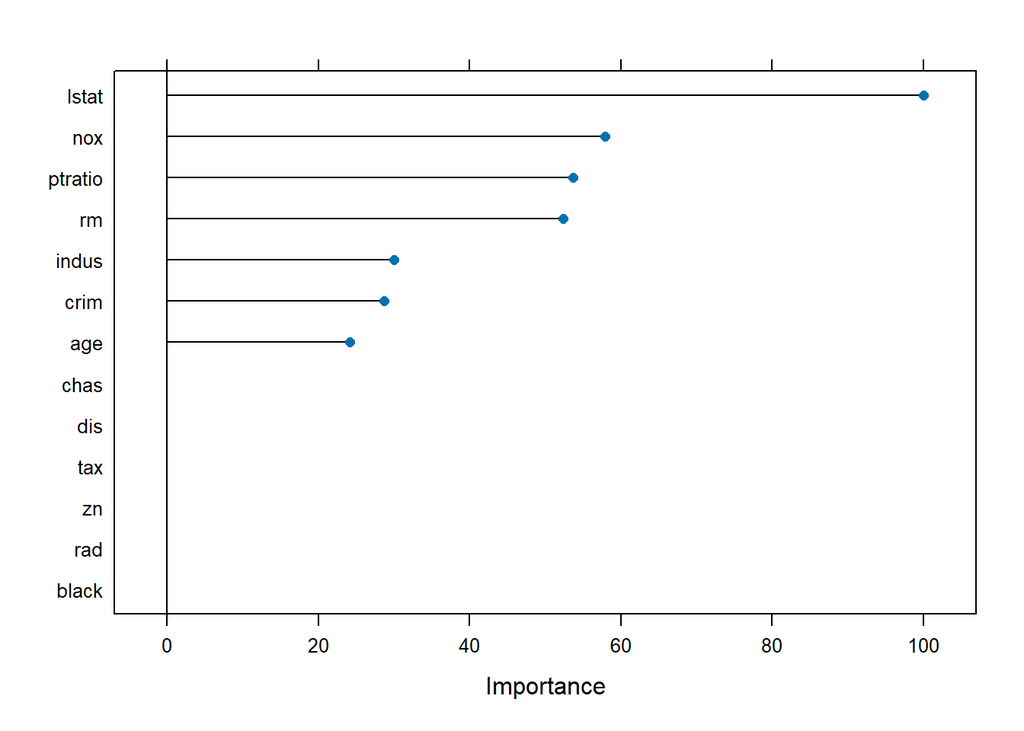

```r
# Plot variable importance
plot(varImp(model_regr))
```

## Ensemble Methods

### Bagging (Bootstrap Aggregating)

Bagging builds multiple decision trees on different random samples (with replacement) of the data, and averages their predictions. For classification, it takes a vote among the trees. Bagging reduces variance and helps prevent overfitting.

### Random Forest

Random Forest builds many decision trees, but at each split, it only considers a random subset of features, adding extra randomness and decorrelation between the trees. This usually improves performance over plain bagging.

### Demo: Bagging

**Hyperparameters**

- For `treebag`, there are no tuning parameters.

```r
set.seed(123)
model_bag <- train(
  Species ~ .,
  data = iris,
  method = "treebag",
  trControl = trainControl(method = "cv", number = 3)
)
print(model_bag)
```

```
## Bagged CART
##
## 150 samples
##   4 predictor
##   3 classes: 'setosa', 'versicolor', 'virginica'
##
## No pre-processing
## Resampling: Cross-Validated (3 fold)
## Summary of sample sizes: 100, 101, 99
## Resampling results:
##
##   Accuracy   Kappa
##   0.9398479  0.9096958
```

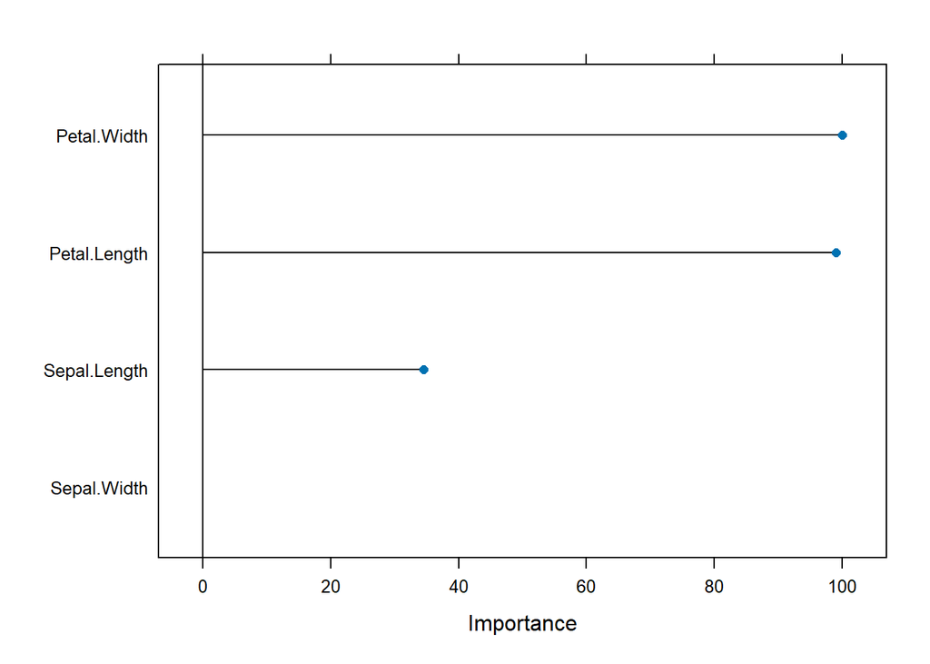

```r
# Plot variable importance
plot(varImp(model_bag))
```

### Demo: Random Forest

**Hyperparameters**

- **mtry:** Number of features randomly selected at each split (default: $\sqrt{number of features}$)
- **ntree:** Number of trees (not tuned by caret, but can be set).
- **maxnodes:** Maximum number of terminal nodes trees can have.

```r
library(randomForest)
set.seed(123)
model_rf <- train(
  Species ~ .,
  data = iris,
  method = "rf",
  trControl = trainControl(method = "cv", number = 3),
  tuneLength = 3
)
print(model_rf)
```

```
## Random Forest
##
## 150 samples
##   4 predictor
##   3 classes: 'setosa', 'versicolor', 'virginica'
##
## No pre-processing
## Resampling: Cross-Validated (3 fold)
## Summary of sample sizes: 100, 101, 99
## Resampling results across tuning parameters:
##
##   mtry  Accuracy   Kappa
##   2     0.9462532  0.9193176
##   3     0.9462532  0.9193176
##   4     0.9462532  0.9193176
##
## Accuracy was used to select the optimal model using the largest value.
## The final value used for the model was mtry = 2.
```

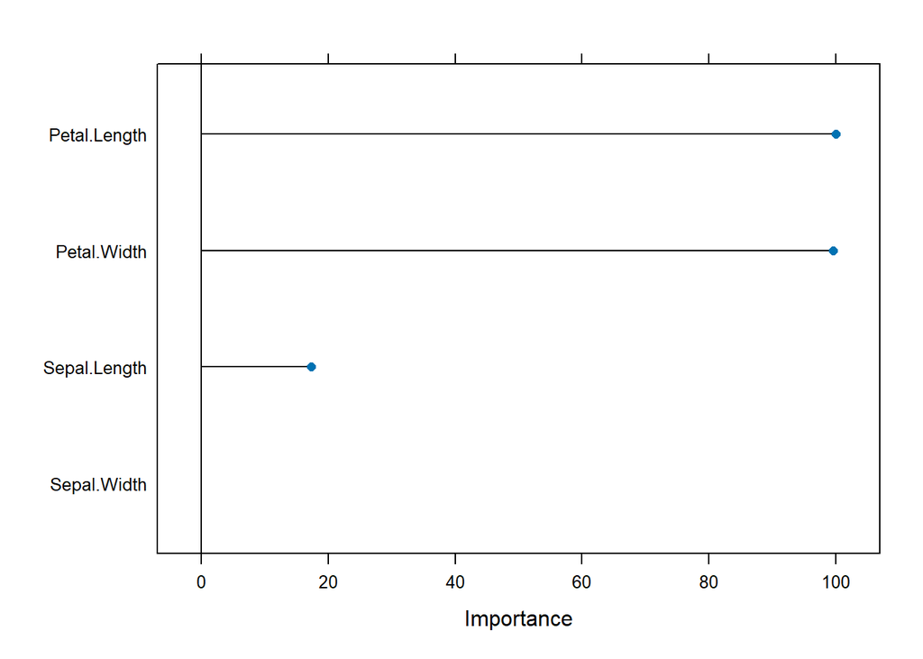

```r
# Plot variable importance
plot(varImp(model_rf))
```

**Interpreting the Output:**

- Accuracy (for classification) or RMSE (for regression).
- Best value of `mtry` found during cross-validation.

## Boosting

### What is Boosting?

Boosting is an ensemble technique that combines many “weak” models (shallow trees) in sequence, where each new model focuses on correcting the errors of the previous ones.

### AdaBoost (Adaptive Boosting)

- Models are added one at a time, typically “weak learners” which perform only slightly better than chance. Decision stumps (single split) are commonly used.
- Each new model pays more attention to cases that previous models misclassified, i.e., higher weights are assigned to the prediction error of the misclassified cases in the loss function.
- The final prediction is a weighted vote of all models based on model accuracy.

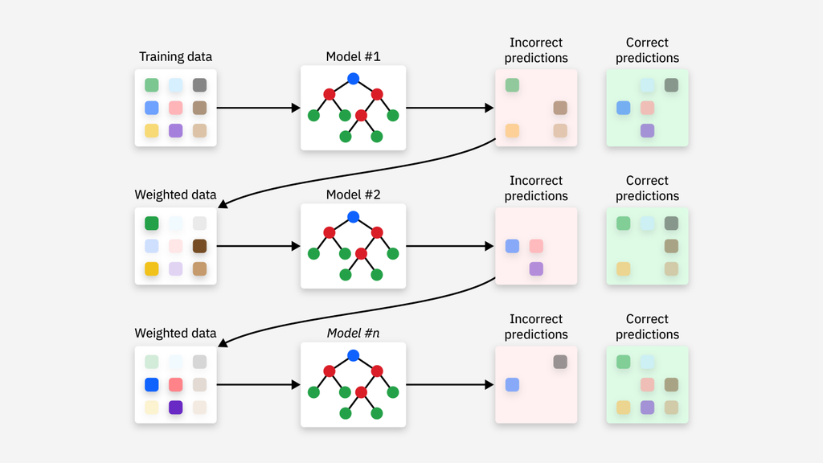

**Pros**

- Intuitive and easy to implement
- Effective, especially for classification
- Handles non-linear relationships

**Cons**

- Sensitive to noise, prone to overfitting
- Computationally expensive, requires many weak learners with large data sets

### Gradient Boosting

- Models are built sequentially to correct the “residual errors” of the previous model.
- Each new model is fit to the difference between the actual value and the prediction so far, i.e. prediction of the residual.
- Usually uses small trees.

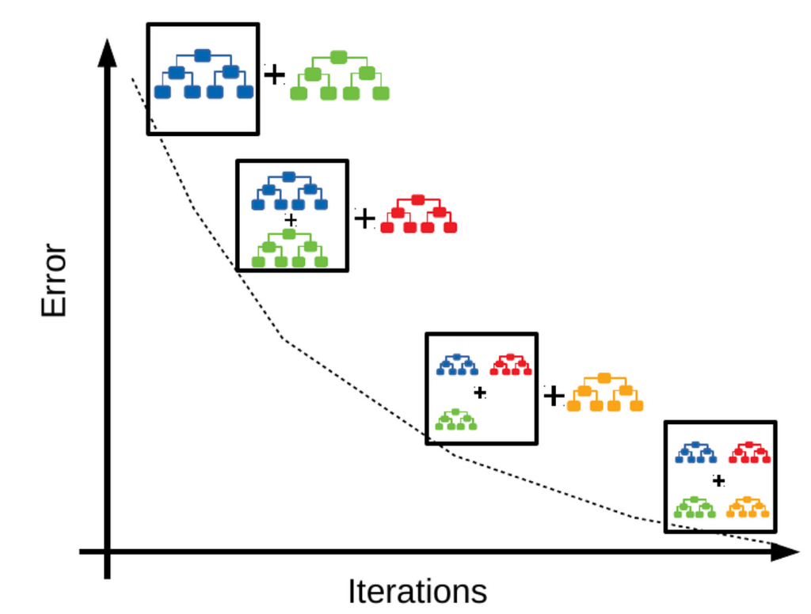

**Pros**

- High accuracy
- Flexibility
- Versatility beyond regression and classification

**Cons**

- Prone to overfitting
- Many hyperparameters which require careful tuning
- Sensitivity to noise and outliers

### Demo: AdaBoost

**Hyperparameters**

```r
library(adabag)
data(GermanCredit)
set.seed(123)
model_ada <- train(
  Class ~ .,
  data = GermanCredit,
  method = "AdaBoost.M1",
  trControl = trainControl(method = "cv", number = 3, verboseIter=TRUE),
  tuneLength = 3
)
print(model_ada)
```

```
## AdaBoost.M1
##
## 1000 samples
##   61 predictor
##    2 classes: 'Bad', 'Good'
##
## No pre-processing
## Resampling: Cross-Validated (3 fold)
## Summary of sample sizes: 666, 667, 667
## Resampling results across tuning parameters:
##
##   coeflearn  maxdepth  mfinal  Accuracy   Kappa
##   Breiman    1          50     0.7359935  0.2746618
##   Breiman    1         100     0.7369885  0.2730205
##   Breiman    1         150     0.7379805  0.2859504
##   Breiman    2          50     0.7499865  0.3545600
##   Breiman    2         100     0.7499775  0.3700797
##   Breiman    2         150     0.7529805  0.3829314
##   Breiman    3          50     0.7489825  0.3612326
##   Breiman    3         100     0.7399975  0.3367332
##   Breiman    3         150     0.7399855  0.3407715
##   Freund     1          50     0.7289925  0.2966058
##   Freund     1         100     0.7339915  0.3179723
##   Freund     1         150     0.7339795  0.3207070
##   Freund     2          50     0.7349775  0.3447969
##   Freund     2         100     0.7519855  0.3684466
##   Freund     2         150     0.7469715  0.3674885
##   Freund     3          50     0.7330025  0.3394427
##   Freund     3         100     0.7279825  0.3304713
##   Freund     3         150     0.7379715  0.3597015
##   Zhu        1          50     0.7379775  0.3113153
##   Zhu        1         100     0.7269785  0.2916951
##   Zhu        1         150     0.7319835  0.3086085
##   Zhu        2          50     0.7180024  0.2943824
##   Zhu        2         100     0.7289895  0.3202324
##   Zhu        2         150     0.7369855  0.3364825
##   Zhu        3          50     0.7440105  0.3652236
##   Zhu        3         100     0.7450025  0.3641187
##   Zhu        3         150     0.7479875  0.3749276
##
## Accuracy was used to select the optimal model using the largest value.
## The final values used for the model were mfinal = 150, maxdepth = 2
##  and coeflearn = Breiman.
```

[figure not shown]

```r
# Plot variable importance
plot(varImp(model_regr))
```

### Demo: Gradient Boosting

**Hyperparameters**

- **n.trees:** Number of trees.
- **interaction.depth:** Maximum depth of each tree.
- **shrinkage:** Learning rate (how much each tree contributes).
- **n.minobsinnode:** Minimum number of observations in each terminal node.

```r
library(gbm)
set.seed(123)
model_gbm <- train(
  Species ~ .,
  data = iris,
  method = "gbm",
  trControl = trainControl(method = "cv", number = 3),
  verbose = FALSE,
  tuneLength = 3
)
print(model_gbm)
```

```
## Stochastic Gradient Boosting
##
## 150 samples
##   4 predictor
##   3 classes: 'setosa', 'versicolor', 'virginica'
##
## No pre-processing
## Resampling: Cross-Validated (3 fold)
## Summary of sample sizes: 100, 101, 99
## Resampling results across tuning parameters:
##
##   interaction.depth  n.trees  Accuracy   Kappa
##   1                   50      0.9463839  0.9194997
##   1                  100      0.9463839  0.9194997
##   1                  150      0.9463839  0.9194997
##   2                   50      0.9398479  0.9096958
##   2                  100      0.9398479  0.9096958
##   2                  150      0.9398479  0.9096958
##   3                   50      0.9398479  0.9096958
##   3                  100      0.9398479  0.9096958
##   3                  150      0.9398479  0.9096958
##
## Tuning parameter 'shrinkage' was held constant at a value of 0.1
##
## Tuning parameter 'n.minobsinnode' was held constant at a value of 10
## Accuracy was used to select the optimal model using the largest value.
## The final values used for the model were n.trees = 50, interaction.depth =
##  1, shrinkage = 0.1 and n.minobsinnode = 10.
```

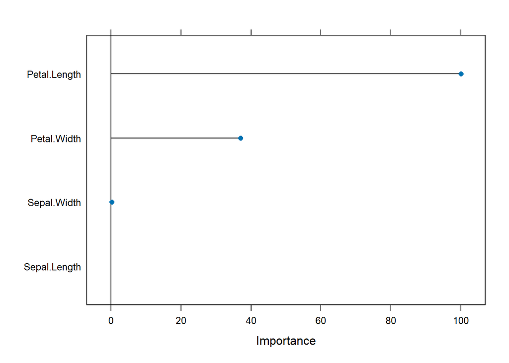

```r
# Plot variable importance
plot(varImp(model_gbm))
```

## Lab

### Exercise 1: Classification Tree

**Dataset:** `Sonar` (from the `mlbench` package)

**Description:** The Sonar dataset contains 208 observations of sonar signals bounced off a metal cylinder (mine) or a roughly cylindrical rock. Each row contains 60 numeric features representing the energy in various frequency bands, and the target variable `Class` indicates whether the object was a mine or a rock.

**Task:** Build and tune a classification tree to predict `Class` (mine or rock) from all sonar signal features.

### Exercise 2: Regression Tree

**Dataset:** `concrete` (from the `modeldata` package)

**Description:** The concrete dataset consists of 1,030 observations on 8 predictor variables describing the ingredients and age of concrete samples. The target variable is `compressive_strength`, which measures the concrete’s compressive strength in MPa.

**Task:** Predict `compressive_strength` using a regression tree and tune its complexity.

### Exercise 3: Random Forest

**Dataset:** `titanic_train` (from the `titanic` package)

**Description:** This dataset contains information on passengers of the Titanic, including their class, sex, age, family aboard, fare paid, and whether they survived. The target variable `Survived` indicates if the passenger survived (1) or not (0).

**Task:** Use random forest to predict `Survived`.

### Exercise 4: Gradient Boosting

**Dataset:** `ames` (from the `modeldata` package)

**Description:** The Ames Housing dataset contains detailed information on home sales in Ames, Iowa, including 80 features for nearly 3,000 homes. In this lab, you’ll use a simplified subset of predictors (all numeric) to predict `Sale_Price`.

**Task:** Predict `Sale_Price` using a gradient boosting model (`gbm`). Use only the following predictors: `Gr_Liv_Area`, `Year_Built`, `Lot_Area`, and `Garage_Cars`.